# Biostat 203B Homework 2

Due Feb 6 @ 11:59PM

Michael Markot

```r
knitr::opts_chunk$set(echo = TRUE, cache = TRUE, cache.lazy = FALSE)
library(tidyverse)
library(data.table)
library(lubridate)
```

```r
os <- sessionInfo()$running
if (str_detect(os, "Linux")) {
  mimic_path <- "/mnt/mimiciv/1.0"
} else if (str_detect(os, "macOS")) {
  mimic_path <- "/Users/huazhou/Documents/Box Sync/MIMIC/mimic-iv-1.0"
}

mimic_path <- "/mnt/mimiciv/1.0"
```

In this exercise, we use tidyverse (ggpot2, dplyr, etc) to explore the [MIMIC-IV](https://mimic.mit.edu/docs/iv/) data introduced in [homework 1](https://ucla-biostat-203b.github.io/2022winter/hw/hw1/hw1.html) and to build a cohort of ICU stays.

```r
# tree -s -L 2 /Users/huazhou/Documents/Box\ Sync/MIMIC/mimic-iv-1.0
system(str_c("tree -s -L 2 ", shQuote(mimic_path)), intern = TRUE)
```

```
##  [1] "/mnt/mimiciv/1.0"
##  [2] "├── [       4096]  core"
##  [3] "│   ├── [   17208966]  admissions.csv.gz"
##  [4] "│   ├── [        606]  index.html"
##  [5] "│   ├── [    2955582]  patients.csv.gz"
##  [6] "│   └── [   53014503]  transfers.csv.gz"
##  [7] "├── [       4096]  hosp"
##  [8] "│   ├── [     430049]  d_hcpcs.csv.gz"
##  [9] "│   ├── [   29531152]  diagnoses_icd.csv.gz"
## [10] "│   ├── [     863239]  d_icd_diagnoses.csv.gz"
## [11] "│   ├── [     579998]  d_icd_procedures.csv.gz"
## [12] "│   ├── [      14898]  d_labitems.csv.gz"
## [13] "│   ├── [   11684062]  drgcodes.csv.gz"
## [14] "│   ├── [  515763427]  emar.csv.gz"
## [15] "│   ├── [  476252563]  emar_detail.csv.gz"
```

[output cut: 26 more lines]

## Q1. `read.csv` (base R) vs `read_csv` (tidyverse) vs `fread` (data.table)

There are quite a few utilities in R for reading plain text data files. Let us test the speed of reading a moderate sized compressed csv file, `admissions.csv.gz`, by three programs: `read.csv` in base R, `read_csv` in tidyverse, and `fread` in the popular data.table package.

```r
system.time(read.csv("/mnt/mimiciv/1.0/core/admissions.csv.gz"))
```

```
##    user  system elapsed
##  46.029   0.207  47.536
```

```r
system.time(read_csv("/mnt/mimiciv/1.0/core/admissions.csv.gz"))
```

```
##    user  system elapsed
##   3.628   0.254   2.471
```

```r
system.time(fread("/mnt/mimiciv/1.0/core/admissions.csv.gz"))
```

```
##    user  system elapsed
##   1.861   0.117   1.071
```

Which function is fastest? Is there difference in the (default) parsed data types? (Hint: R function `system.time` measures run times.)

**Solution:** The ‘fread’ function is fastest, followed clsoely by ‘read_csv’. ‘read.csv’ was the slowest by more than a factor of ten. ‘read_csv’ classifies the time variables as date time data types whereas ‘read.csv’ classifies these by default as numeric.

For later questions, we stick to the tidyverse.

## Q2. ICU stays

`icustays.csv.gz` (https://mimic.mit.edu/docs/iv/modules/icu/icustays/) contains data about Intensive Care Units (ICU) stays. The first 10 lines are

```r
system(
  str_c(
    "zcat < ",
    shQuote(str_c(mimic_path, "/icu/icustays.csv.gz")),
    " | head"
    ),
  intern = TRUE
)
```

```
##  [1] "subject_id,hadm_id,stay_id,first_careunit,last_careunit,intime,outtime,los"
##  [2] "17867402,24528534,31793211,Trauma SICU (TSICU),Trauma SICU (TSICU),2154-03-03 04:11:00,2154-03-04 18:16:56,1.5874537037037035"
##  [3] "14435996,28960964,31983544,Trauma SICU (TSICU),Trauma SICU (TSICU),2150-06-19 17:57:00,2150-06-22 18:33:54,3.025625"
##  [4] "17609946,27385897,33183475,Trauma SICU (TSICU),Trauma SICU (TSICU),2138-02-05 18:54:00,2138-02-15 12:42:05,9.741724537037038"
##  [5] "18966770,23483021,34131444,Trauma SICU (TSICU),Trauma SICU (TSICU),2123-10-25 10:35:00,2123-10-25 18:59:47,0.35054398148148147"
##  [6] "12776735,20817525,34547665,Neuro Stepdown,Neuro Stepdown,2200-07-12 00:33:00,2200-07-13 16:44:40,1.6747685185185184"
##  [7] "10215159,24283593,34569476,Trauma SICU (TSICU),Trauma SICU (TSICU),2124-09-20 15:05:29,2124-09-21 22:06:58,1.2926967592592593"
##  [8] "14489052,26516390,35056286,Trauma SICU (TSICU),Trauma SICU (TSICU),2118-10-26 10:33:56,2118-10-26 20:28:10,0.4126620370370371"
##  [9] "15914763,28906020,36909804,Trauma SICU (TSICU),Trauma SICU (TSICU),2176-12-14 12:00:00,2176-12-17 11:47:01,2.9909837962962964"
## [10] "16256226,20013290,39289362,Neuro Stepdown,Neuro Stepdown,2150-12-20 16:09:08,2150-12-21 14:58:40,0.9510648148148149"
```

1. Import `icustatys.csv.gz` as a tibble `icustays_tble`.

```r
icustays_tble <- read_csv("/mnt/mimiciv/1.0/icu/icustays.csv.gz")
```

2. How many unique `subject_id`? Can a `subject_id` have multiple ICU stays?

```r
length(unique(icustays_tble$subject_id))
```

```
## [1] 53150
```

**Solution:** There are 53,150 unique subject ID’s. There are more total observations than unique subject ID’s so a subject ID must be able to have multiple stays.

3. For each `subject_id`, let’s only keep the first ICU stay in the tibble `icustays_tble`.

```r
icustays_tble <- icustays_tble %>%
                   group_by(subject_id) %>%
                   arrange(intime) %>%
                   distinct(subject_id, .keep_all = TRUE)
```

## Q3. `admission` data

Information of the patients admitted into hospital is available in `admissions.csv.gz`. See https://mimic.mit.edu/docs/iv/modules/core/admissions/ for details of each field in this file. The first 10 lines are

```r
system(
  str_c(
    "zcat < ",
    shQuote(str_c(mimic_path, "/core/admissions.csv.gz")),
    " | head"
    ),
  intern = TRUE
)
```

```
##  [1] "subject_id,hadm_id,admittime,dischtime,deathtime,admission_type,admission_location,discharge_location,insurance,language,marital_status,ethnicity,edregtime,edouttime,hospital_expire_flag"
##  [2] "14679932,21038362,2139-09-26 14:16:00,2139-09-28 11:30:00,,ELECTIVE,,HOME,Other,ENGLISH,SINGLE,UNKNOWN,,,0"
##  [3] "15585972,24941086,2123-10-07 23:56:00,2123-10-12 11:22:00,,ELECTIVE,,HOME,Other,ENGLISH,,WHITE,,,0"
##  [4] "11989120,21965160,2147-01-14 09:00:00,2147-01-17 14:25:00,,ELECTIVE,,HOME,Other,ENGLISH,,UNKNOWN,,,0"
##  [5] "17817079,24709883,2165-12-27 17:33:00,2165-12-31 21:18:00,,ELECTIVE,,HOME,Other,ENGLISH,,OTHER,,,0"
##  [6] "15078341,23272159,2122-08-28 08:48:00,2122-08-30 12:32:00,,ELECTIVE,,HOME,Other,ENGLISH,,BLACK/AFRICAN AMERICAN,,,0"
##  [7] "19124609,20517215,2169-03-14 12:44:00,2169-03-20 19:15:00,,ELECTIVE,,HOME,Other,ENGLISH,,UNKNOWN,,,0"
##  [8] "17301855,29732723,2140-06-06 14:23:00,2140-06-08 14:25:00,,ELECTIVE,,HOME,Other,ENGLISH,,WHITE,,,0"
##  [9] "17991012,24298836,2181-07-10 20:28:00,2181-07-12 15:49:00,,ELECTIVE,,HOME,Other,ENGLISH,,WHITE,,,0"
## [10] "16865435,23216961,2185-07-19 02:12:00,2185-07-21 11:50:00,,ELECTIVE,,HOME,Other,ENGLISH,,WHITE,,,0"
```

1. Import `admissions.csv.gz` as a tibble `admissions_tble`.

```r
admissions_tble <- read_csv("/mnt/mimiciv/1.0/core/admissions.csv.gz")
```

2. Let’s only keep the admissions that have a match in `icustays_tble` according to `subject_id` and `hadmi_id`.

```r
admissions_tble <- admissions_tble %>%
  semi_join(icustays_tble, by = "subject_id", "hadm_id")
```

3. Summarize the following variables by graphics.
- admission year

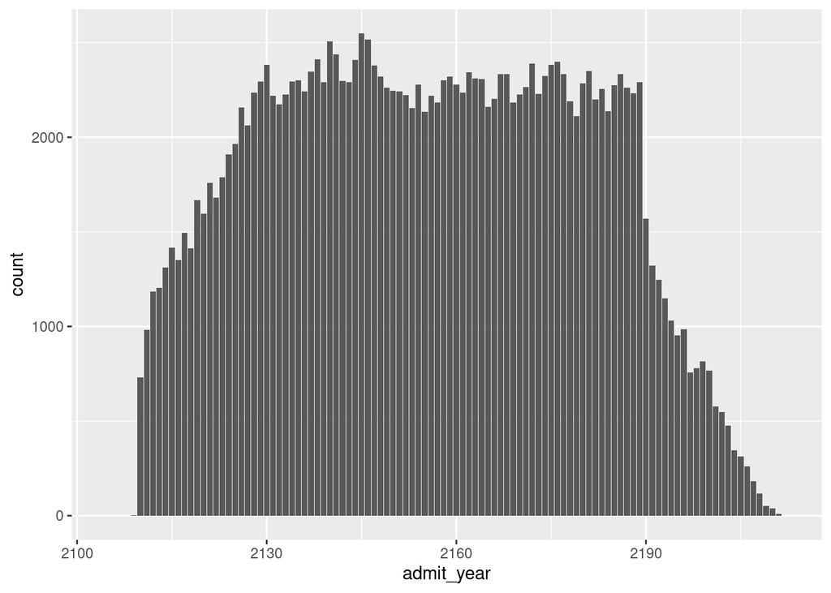

```r
admissions_tble$admit_year <- year(admissions_tble$admittime)
ggplot(data = admissions_tble) +
  geom_bar(mapping = aes(admit_year))
```

- admission month

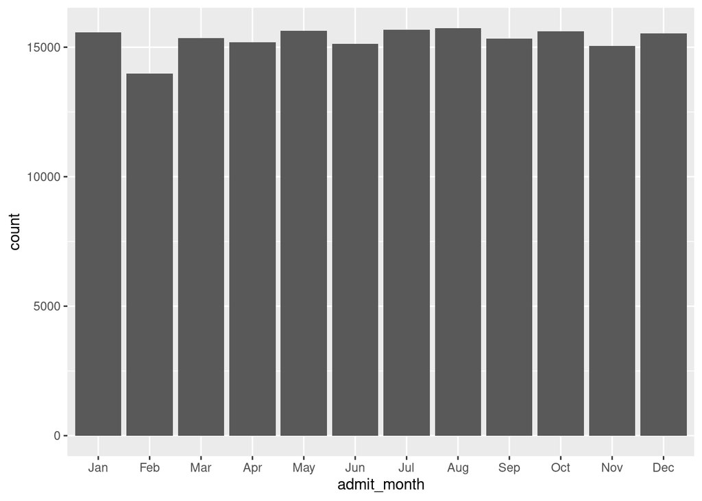

```r
admissions_tble$admit_month <- month(admissions_tble$admittime, label = TRUE)
ggplot(data = admissions_tble) +
  geom_bar(mapping = aes(admit_month))
```

- admission month day

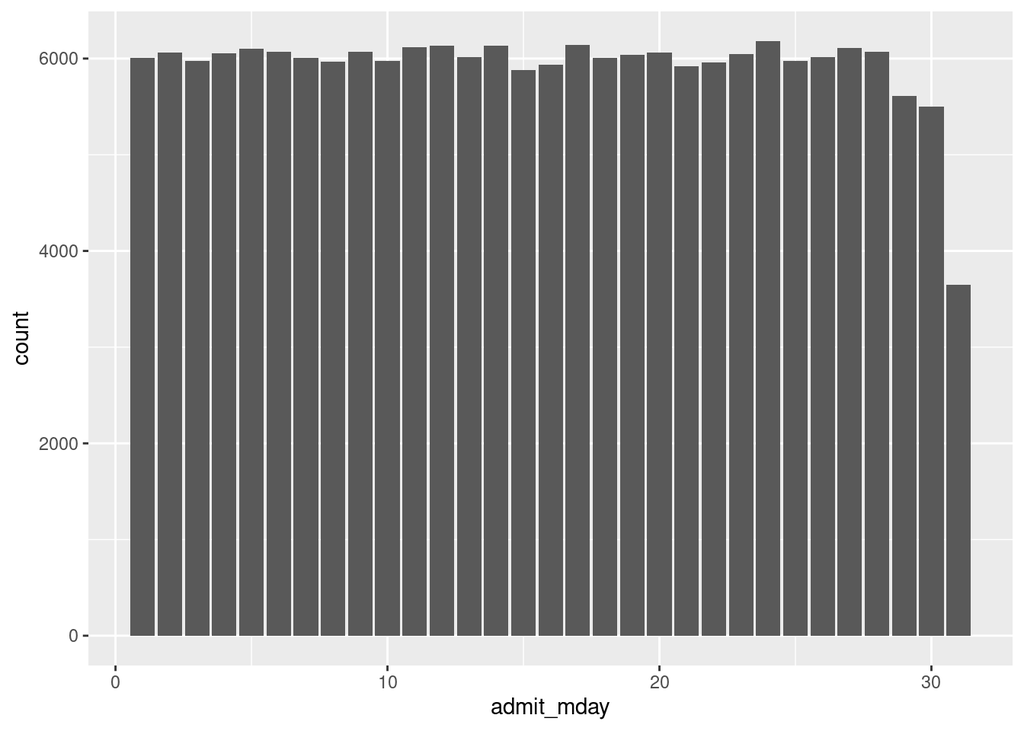

```r
admissions_tble$admit_mday <- mday(admissions_tble$admittime)
ggplot(data = admissions_tble) +
  geom_bar(mapping = aes(admit_mday))
```

- admission week day

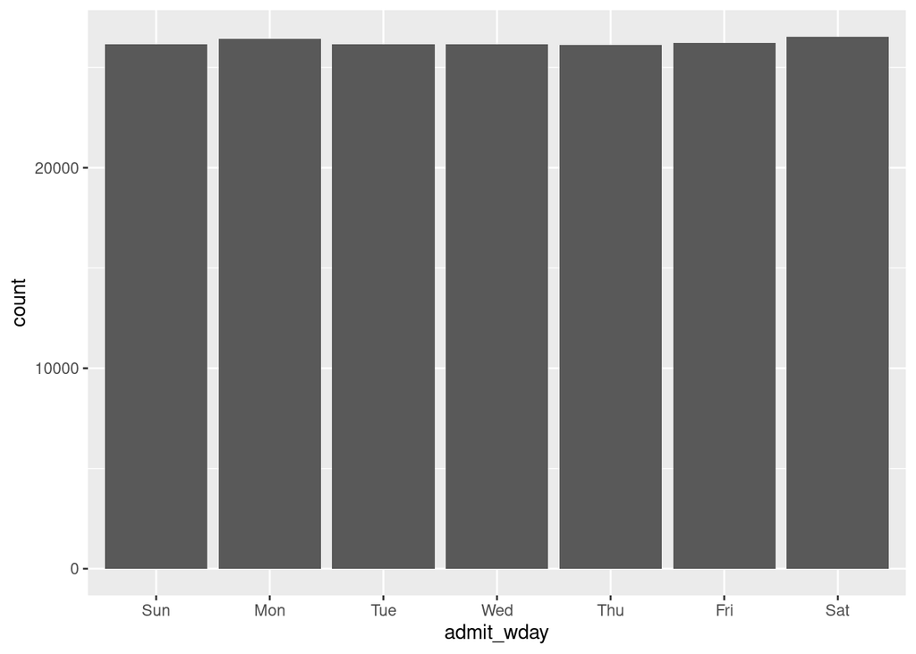

```r
admissions_tble$admit_wday <- wday(admissions_tble$admittime, label = TRUE)
ggplot(data = admissions_tble) +
  geom_bar(mapping = aes(admit_wday))
```

- admission hour (anything unusual?)

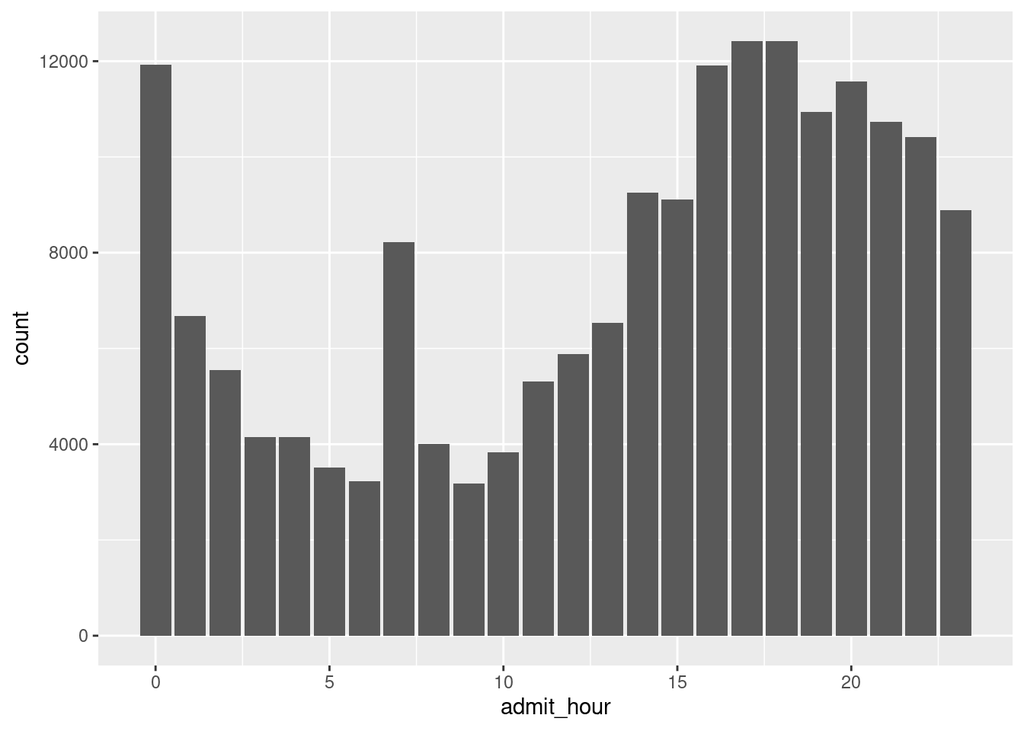

```r
admissions_tble$admit_hour <- hour(admissions_tble$admittime)
ggplot(data = admissions_tble) +
  geom_bar(mapping = aes(admit_hour))
```

**Solution:** There is a large spike in admissions at 7am compared to the hours preceding and following it. This could be when most people wake up and decide they need to go to the hospital, when there is a staffing increase at the hospital for the beginning of the work day, or another unknown factor.

## Q4. `patients` data

Patient information is available in `patients.csv.gz`. See https://mimic.mit.edu/docs/iv/modules/core/patients/ for details of each field in this file. The first 10 lines are

```r
system(
  str_c(
    "zcat < ",
    shQuote(str_c(mimic_path, "/core/patients.csv.gz")),
    " | head"
    ),
  intern = TRUE
)
```

```
##  [1] "subject_id,gender,anchor_age,anchor_year,anchor_year_group,dod"
##  [2] "10000048,F,23,2126,2008 - 2010,"
##  [3] "10002723,F,0,2128,2017 - 2019,"
##  [4] "10003939,M,0,2184,2008 - 2010,"
##  [5] "10004222,M,0,2161,2014 - 2016,"
##  [6] "10005325,F,0,2154,2011 - 2013,"
##  [7] "10007338,F,0,2153,2017 - 2019,"
##  [8] "10008101,M,0,2142,2008 - 2010,"
##  [9] "10009872,F,0,2168,2014 - 2016,"
## [10] "10011333,F,0,2132,2014 - 2016,"
```

1. Import `patients.csv.gz` (https://mimic.mit.edu/docs/iv/modules/core/patients/) as a tibble `patients_tble` and only keep the patients who have a match in `icustays_tble` (according to `subject_id`).

```r
patients_tble <- read_csv("/mnt/mimiciv/1.0/core/patients.csv.gz")
patients_tble <- patients_tble %>%
  semi_join(icustays_tble, by = "subject_id")
```

2. Summarize variables `gender` and `anchor_age`, and explain any patterns you see.

```r
patients_tble$gender <- as.factor(patients_tble$gender)
summary.factor(patients_tble$gender)
```

```
##     F     M
## 23353 29797
```

```r
summary(patients_tble$anchor_age)
```

```
##    Min. 1st Qu.  Median    Mean 3rd Qu.    Max.
##   18.00   53.00   65.00   63.51   77.00   91.00
```

**Solution:** There are 56% males comapred to females and the age seems to be consist of many more older people than younger people with the mean and median being over 60. This makes sense since older people are more likly to need the hospital than younger peolpe in general. Also the minimum age is 18 so we can assume that children were excluded from this data.

## Q5. Lab results

`labevents.csv.gz` (https://mimic.mit.edu/docs/iv/modules/hosp/labevents/) contains all laboratory measurements for patients. The first 10 lines are

```r
system(
  str_c(
    "zcat < ",
    shQuote(str_c(mimic_path, "/hosp/labevents.csv.gz")),
    " | head"
    ),
  intern = TRUE
)
```

```
##  [1] "labevent_id,subject_id,hadm_id,specimen_id,itemid,charttime,storetime,value,valuenum,valueuom,ref_range_lower,ref_range_upper,flag,priority,comments"
##  [2] "670,10000048,,6448755,51484,2126-11-22 19:20:00,2126-11-22 20:07:00,150,150,mg/dL,,,,STAT,"
##  [3] "673,10000048,,6448755,51491,2126-11-22 19:20:00,2126-11-22 20:07:00,6.5,6.5,units,5,8,,STAT,"
##  [4] "675,10000048,,6448755,51498,2126-11-22 19:20:00,2126-11-22 20:07:00,1.029,1.029, ,1.001,1.035,,STAT,"
##  [5] "683,10000048,,82729055,50861,2126-11-22 20:45:00,2126-11-23 00:55:00,39,39,IU/L,0,40,,STAT,"
##  [6] "684,10000048,,82729055,50862,2126-11-22 20:45:00,2126-11-23 00:55:00,4.7,4.7,g/dL,3.4,4.8,,STAT,"
##  [7] "685,10000048,,82729055,50863,2126-11-22 20:45:00,2126-11-23 00:55:00,45,45,IU/L,39,117,,STAT,"
##  [8] "686,10000048,,82729055,50868,2126-11-22 20:45:00,2126-11-22 21:32:00,13,13,mEq/L,8,20,,STAT,"
##  [9] "687,10000048,,82729055,50878,2126-11-22 20:45:00,2126-11-23 00:55:00,28,28,IU/L,0,40,,STAT,"
## [10] "688,10000048,,82729055,50882,2126-11-22 20:45:00,2126-11-22 21:32:00,26,26,mEq/L,22,32,,STAT,"
```

`d_labitems.csv.gz` is the dictionary of lab measurements.

```r
system(
  str_c(
    "zcat < ",
    shQuote(str_c(mimic_path, "/hosp/d_labitems.csv.gz")),
    " | head"
    ),
  intern = TRUE
)
```

```
##  [1] "itemid,label,fluid,category,loinc_code"
##  [2] "51905, ,Other Body Fluid,Chemistry,"
##  [3] "51532,11-Deoxycorticosterone,Blood,Chemistry,"
##  [4] "51957,17-Hydroxycorticosteroids,Urine,Chemistry,"
##  [5] "51958,\"17-Ketosteroids, Urine\",Urine,Chemistry,"
##  [6] "52068,24 Hr,Blood,Hematology,"
##  [7] "51066,24 hr Calcium,Urine,Chemistry,"
##  [8] "51067,24 hr Creatinine,Urine,Chemistry,"
##  [9] "51068,24 hr Protein,Urine,Chemistry,"
## [10] "50853,25-OH Vitamin D,Blood,Chemistry,"
```

1. Find how many rows are in `labevents.csv.gz`.

```bash
wc -l "/mnt/mimiciv/1.0/hosp/labevents.csv.gz"
```

```
## 8398755 /mnt/mimiciv/1.0/hosp/labevents.csv.gz
```

2. We are interested in the lab measurements of creatinine (50912), potassium (50971), sodium (50983), chloride (50902), bicarbonate (50882), hematocrit (51221), white blood cell count (51301), glucose (50931), magnesium (50960), and calcium (50893). Retrieve a subset of `labevents.csv.gz` only containing these items for the patients in `icustays_tble` as a tibble `labevents_tble`.

   Hint: `labevents.csv.gz` is a data file too big to be read in by the `read_csv` function in its default setting. Utilize the `col_select` and `lazy` options in the `read_csv` function to reduce the memory burden.

```r
labpath <- "/mnt/mimiciv/1.0/hosp/labevents_filtered_itemid.csv.gz"
labevents_tble <- read_csv(labpath)
labevents_tble <- labevents_tble %>%
  semi_join(icustays_tble, by = "subject_id")
```

3. Further restrict `labevents_tble` to the first lab measurement during the ICU stay.

```r
labevents_tble <- labevents_tble %>%
  group_by(subject_id, charttime) %>%
  pivot_wider(id_cols = c(subject_id, charttime),
    names_from = itemid, values_from = valuenum)
```

```r
labevents_tble <- labevents_tble %>%
                     group_by(subject_id) %>%
                     arrange(charttime) %>%
                     distinct(subject_id, .keep_all = TRUE)
```

```r
labevents_tble <- labevents_tble %>%
  mutate(`50882` = ifelse(`50882` == "NULL", NA, unlist(`50882`)) %>%
           as.numeric)

labevents_tble <- labevents_tble %>%
  mutate(`50902` = ifelse(`50902` == "NULL", NA, unlist(`50902`)) %>%
           as.numeric)

labevents_tble <- labevents_tble %>%
  mutate(`50912` = ifelse(`50912` == "NULL", NA, unlist(`50912`)) %>%
           as.numeric)

labevents_tble <- labevents_tble %>%
  mutate(`50931` = ifelse(`50931` == "NULL", NA, unlist(`50931`)) %>%
           as.numeric)

labevents_tble <- labevents_tble %>%
  mutate(`50971` = ifelse(`50971` == "NULL", NA, unlist(`50971`)) %>%
           as.numeric)

labevents_tble <- labevents_tble %>%
  mutate(`50983` = ifelse(`50983` == "NULL", NA, unlist(`50983`)) %>%
           as.numeric)

labevents_tble <- labevents_tble %>%
  mutate(`51221` = ifelse(`51221` == "NULL", NA, unlist(`51221`)) %>%
           as.numeric)

labevents_tble <- labevents_tble %>%
  mutate(`51301` = ifelse(`51301` == "NULL", NA, unlist(`51301`)) %>%
           as.numeric)

labevents_tble <- labevents_tble %>%
  mutate(`50893` = ifelse(`50893` == "NULL", NA, unlist(`50893`)) %>%
           as.numeric)

labevents_tble <- labevents_tble %>%
  mutate(`50960` = ifelse(`50960` == "NULL", NA, unlist(`50960`)) %>%
           as.numeric)
```

4. Summarize the lab measurements by appropriate numerics and graphics.

```r
names(labevents_tble) <- c('subject_id', 'charttimelabs', 'bicarbonate',
                       'chloride', 'creatinine', 'glucose', 'potassium',
                       'sodium', 'hematocrit', 'white_blood_cell_count',
                       'calcium','magnesium')
```

```r
labevents_tble <- labevents_tble %>%
  mutate(creatinine = ifelse(creatinine > 100, NA, unlist(creatinine)) %>%
           as.numeric)

labevents_tble <- labevents_tble %>%
  mutate(white_blood_cell_count = ifelse(white_blood_cell_count > 200, NA,
    unlist(white_blood_cell_count)) %>%
    as.numeric)

labevents_tble <- labevents_tble %>%
  mutate(white_blood_cell_count = ifelse(white_blood_cell_count > 200, NA,
    unlist(white_blood_cell_count)) %>%
    as.numeric)
```

```r
summary(labevents_tble[3:12])
```

```
##   bicarbonate       chloride       creatinine        glucose
##  Min.   : 2.00   Min.   : 46.0   Min.   : 0.000   Min.   :   6
##  1st Qu.:22.00   1st Qu.: 99.0   1st Qu.: 0.800   1st Qu.:  96
##  Median :25.00   Median :102.0   Median : 1.000   Median : 114
##  Mean   :24.71   Mean   :101.8   Mean   : 1.251   Mean   : 137
##  3rd Qu.:27.00   3rd Qu.:105.0   3rd Qu.: 1.200   3rd Qu.: 149
##  Max.   :50.00   Max.   :140.0   Max.   :43.000   Max.   :2340
##  NA's   :10995   NA's   :9818    NA's   :3684     NA's   :12774
##    potassium          sodium        hematocrit    white_blood_cell_count
##  Min.   : 1.300   Min.   : 96.0   Min.   : 0.00   Min.   :  0.10
##  1st Qu.: 3.800   1st Qu.:137.0   1st Qu.:33.90   1st Qu.:  6.60
##  Median : 4.200   Median :139.0   Median :38.10   Median :  8.70
##  Mean   : 4.262   Mean   :138.6   Mean   :37.62   Mean   : 10.26
##  3rd Qu.: 4.600   3rd Qu.:141.0   3rd Qu.:41.80   3rd Qu.: 12.10
##  Max.   :10.000   Max.   :180.0   Max.   :69.70   Max.   :199.10
##  NA's   :9280     NA's   :9629    NA's   :4647    NA's   :5030
##     calcium        magnesium
##  Min.   : 0.00   Min.   : 0.00
##  1st Qu.: 8.40   1st Qu.: 1.80
##  Median : 9.00   Median : 2.00
##  Mean   : 8.88   Mean   : 2.01
##  3rd Qu.: 9.40   3rd Qu.: 2.20
##  Max.   :30.00   Max.   :32.00
##  NA's   :32008   NA's   :32675
```

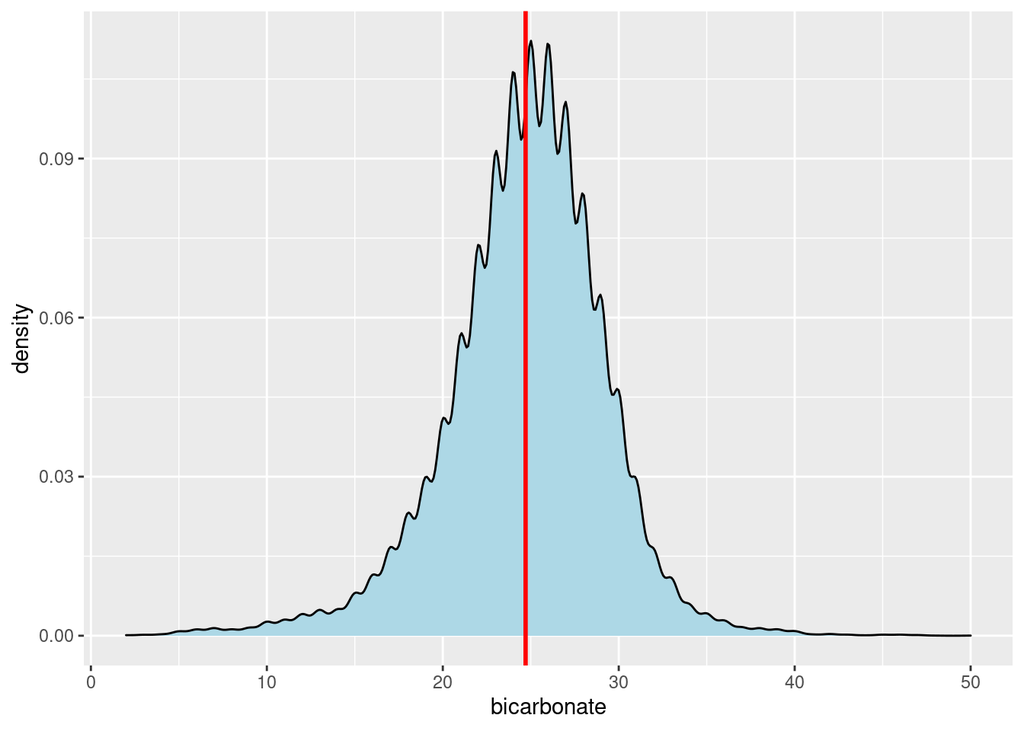

```r
mbicarbonate <- mean(labevents_tble$bicarbonate, na.rm = TRUE)
ggplot(data = labevents_tble) +
  geom_density(mapping = aes(bicarbonate), fill = "light blue") +
  geom_vline(xintercept = mbicarbonate, size = 1, color = "red")
```

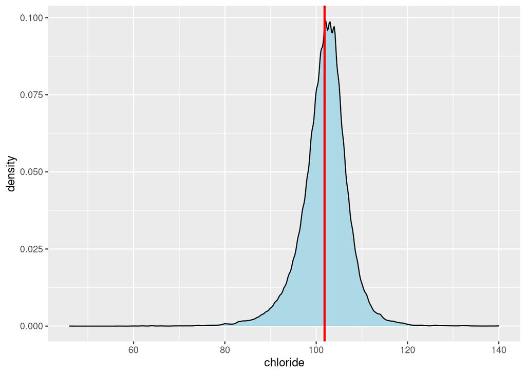

```r
mchloride <- mean(labevents_tble$chloride, na.rm = TRUE)
ggplot(data = labevents_tble) +
  geom_density(mapping = aes(chloride), fill = "light blue") +
  geom_vline(xintercept = mchloride, size = 1, color = "red")
```

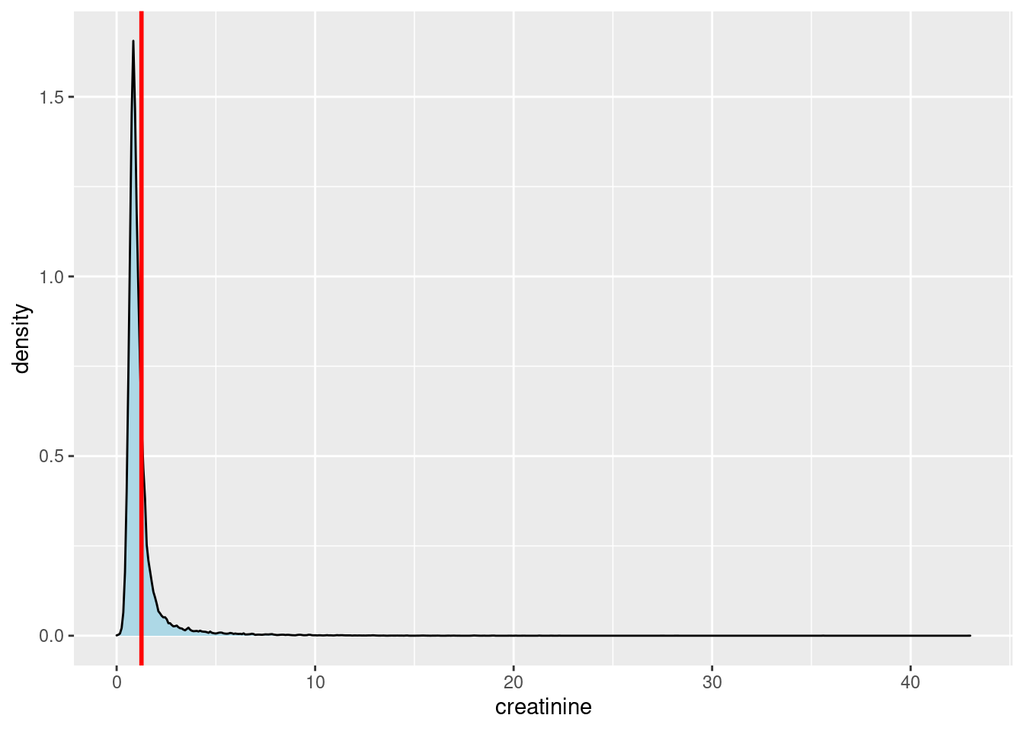

```r
mcreatinine <- mean(labevents_tble$creatinine, na.rm = TRUE)
ggplot(data = labevents_tble) +
  geom_density(mapping = aes(creatinine), fill = "light blue") +
  geom_vline(xintercept = mcreatinine, size = 1, color = "red")
```

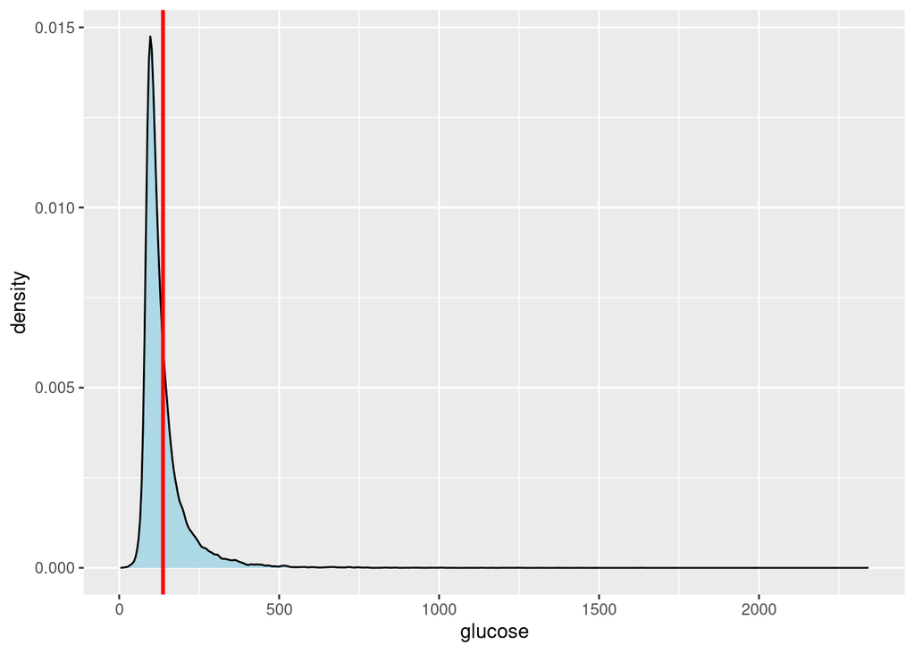

```r
mglucose <- mean(labevents_tble$glucose, na.rm = TRUE)
ggplot(data = labevents_tble) +
  geom_density(mapping = aes(glucose), fill = "light blue") +
  geom_vline(xintercept = mglucose, size = 1, color = "red")
```

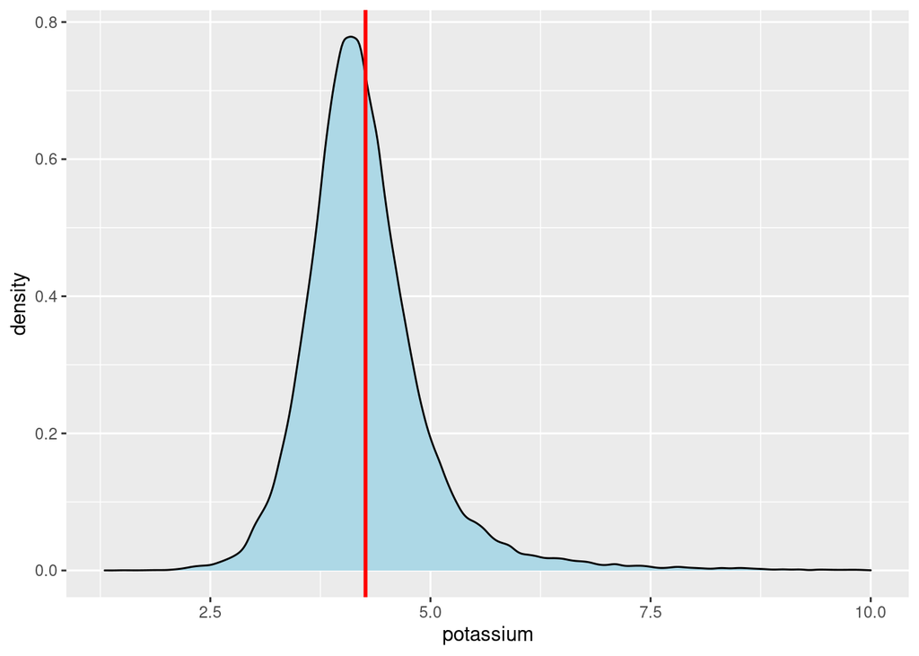

```r
mpotassium <- mean(labevents_tble$potassium, na.rm = TRUE)
ggplot(data = labevents_tble) +
  geom_density(mapping = aes(potassium), fill = "light blue") +
  geom_vline(xintercept = mpotassium, size = 1, color = "red")
```

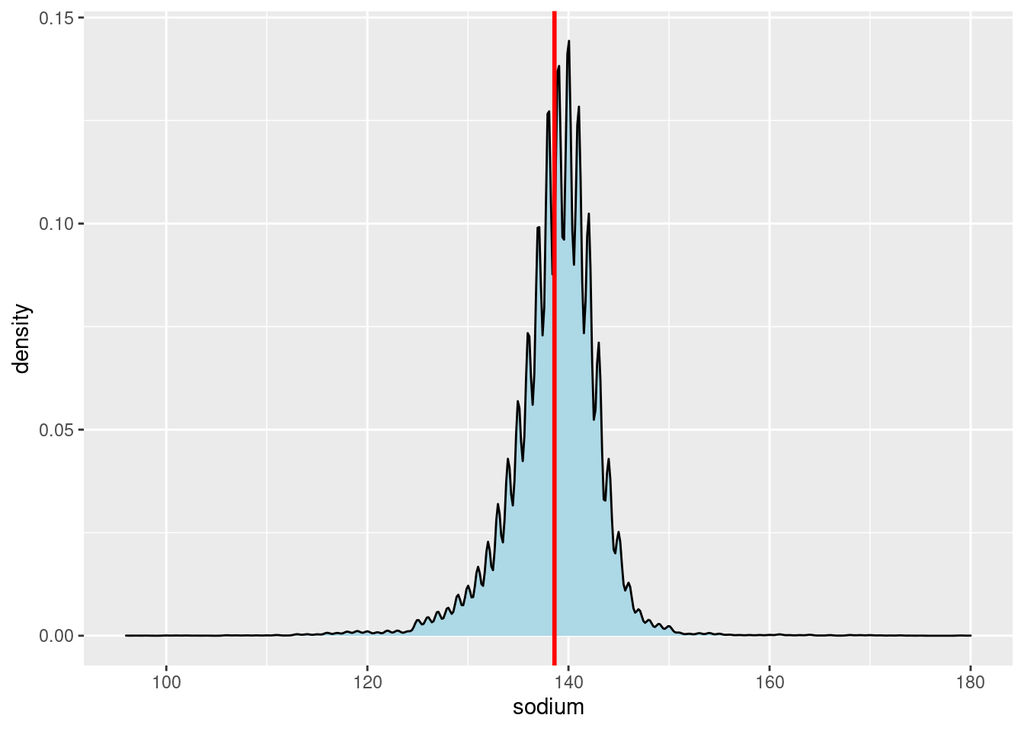

```r
msodium <- mean(labevents_tble$sodium, na.rm = TRUE)
ggplot(data = labevents_tble) +
  geom_density(mapping = aes(sodium), fill = "light blue") +
  geom_vline(xintercept = msodium, size = 1, color = "red")
```

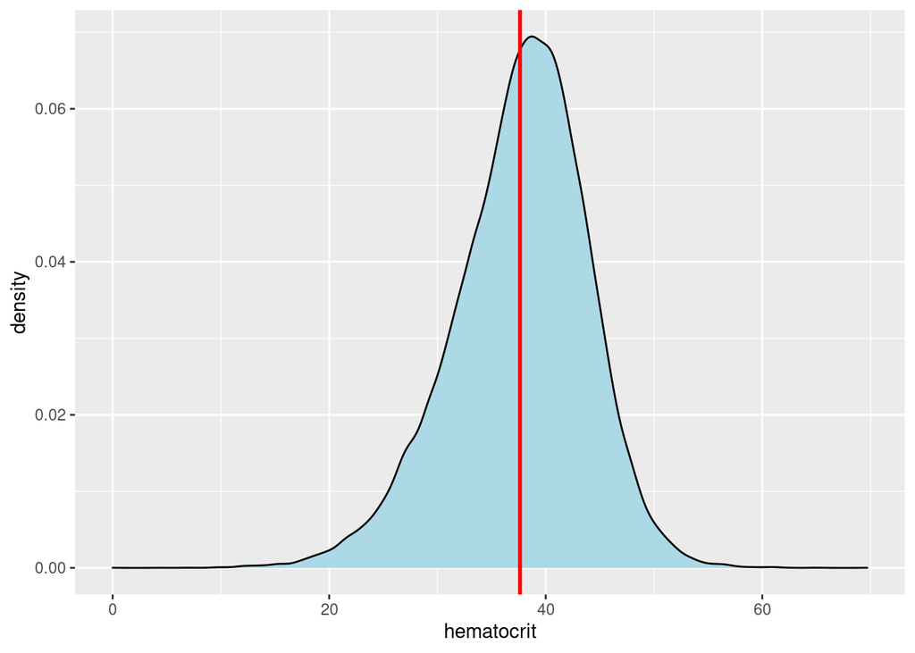

```r
mhematocrit <- mean(labevents_tble$hematocrit, na.rm = TRUE)
ggplot(data = labevents_tble) +
  geom_density(mapping = aes(hematocrit), fill = "light blue") +
  geom_vline(xintercept = mhematocrit, size = 1, color = "red")
```

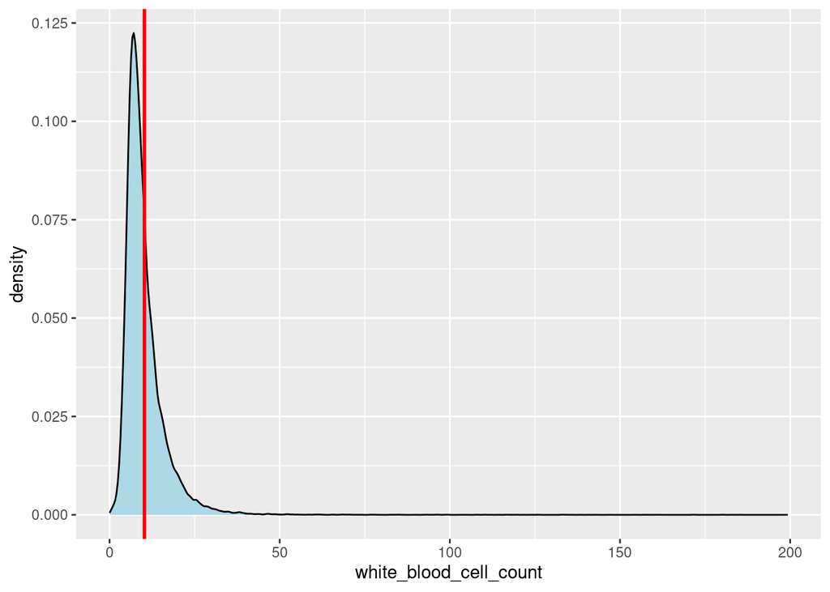

```r
mwhite_blood_cell_count <- mean(labevents_tble$white_blood_cell_count,
                                na.rm = TRUE)
ggplot(data = labevents_tble) +
  geom_density(mapping = aes(white_blood_cell_count), fill = "light blue") +
  geom_vline(xintercept = mwhite_blood_cell_count, size = 1, color = "red")
```

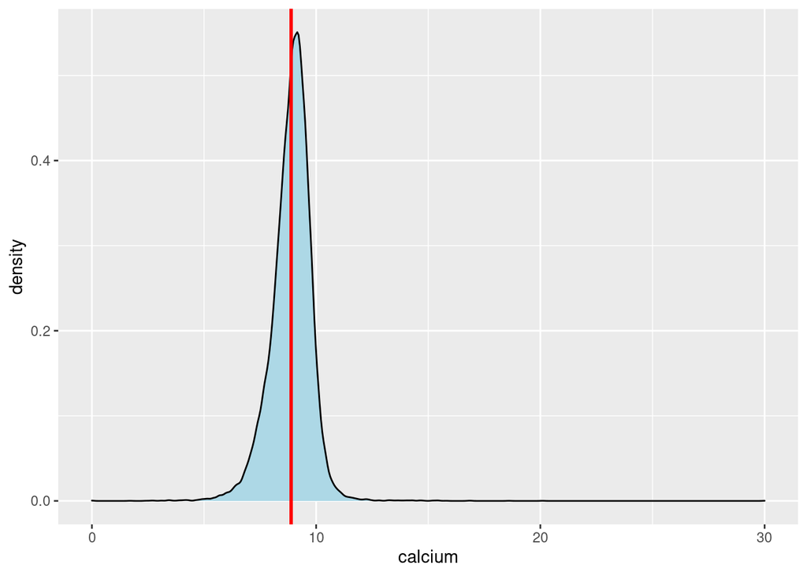

```r
mcalcium <- mean(labevents_tble$calcium, na.rm = TRUE)
ggplot(data = labevents_tble) +
  geom_density(mapping = aes(calcium), fill = "light blue") +
  geom_vline(xintercept = mcalcium, size = 1, color = "red")
```

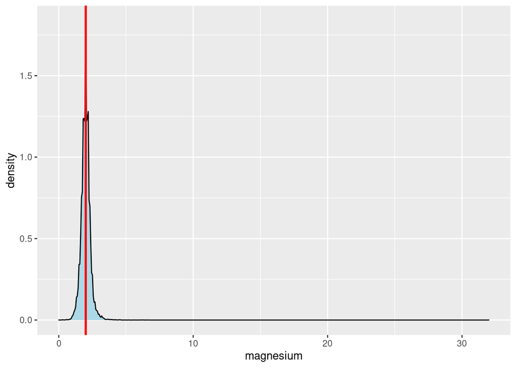

```r
mmagnesium <- mean(labevents_tble$magnesium, na.rm = TRUE)
ggplot(data = labevents_tble) +
  geom_density(mapping = aes(magnesium), fill = "light blue") +
  geom_vline(xintercept = mmagnesium, size = 1, color = "red")
```

## Q6. Vitals from charted events

`chartevents.csv.gz` (https://mimic.mit.edu/docs/iv/modules/icu/chartevents/) contains all the charted data available for a patient. During their ICU stay, the primary repository of a patient’s information is their electronic chart. The `itemid` variable indicates a single measurement type in the database. The `value` variable is the value measured for `itemid`. The first 10 lines of `chartevents.csv.gz` are

```r
system(
  str_c(
    "zcat < ",
    shQuote(str_c(mimic_path, "/icu/chartevents.csv.gz")),
    " | head"),
  intern = TRUE
)
```

```
##  [1] "subject_id,hadm_id,stay_id,charttime,storetime,itemid,value,valuenum,valueuom,warning"
##  [2] "10003700,28623837,30600691,2165-04-24 05:10:00,2165-04-24 05:11:00,228236,0,0,,0"
##  [3] "10003700,28623837,30600691,2165-04-24 05:12:00,2165-04-24 05:14:00,225067,0,0,,0"
##  [4] "10003700,28623837,30600691,2165-04-24 05:12:00,2165-04-24 05:14:00,225070,1,1,,0"
##  [5] "10003700,28623837,30600691,2165-04-24 05:12:00,2165-04-24 05:14:00,225076,1,1,,0"
##  [6] "10003700,28623837,30600691,2165-04-24 05:12:00,2165-04-24 05:14:00,225078,1,1,,0"
##  [7] "10003700,28623837,30600691,2165-04-24 05:12:00,2165-04-24 05:14:00,225086,1,1,,0"
##  [8] "10003700,28623837,30600691,2165-04-24 05:12:00,2165-04-24 05:14:00,225091,1,1,,0"
##  [9] "10003700,28623837,30600691,2165-04-24 05:12:00,2165-04-24 05:14:00,225103,1,1,,0"
## [10] "10003700,28623837,30600691,2165-04-24 05:12:00,2165-04-24 05:14:00,225106,1,1,,0"
```

`d_items.csv.gz` (https://mimic.mit.edu/docs/iv/modules/icu/d_items/) is the dictionary for the `itemid` in `chartevents.csv.gz`.

```r
system(
  str_c(
    "zcat < ",
    shQuote(str_c(mimic_path, "/icu/d_items.csv.gz")),
    " | head"),
  intern = TRUE
)
```

```
##  [1] "itemid,label,abbreviation,linksto,category,unitname,param_type,lownormalvalue,highnormalvalue"
##  [2] "220003,ICU Admission date,ICU Admission date,datetimeevents,ADT,,Date and time,,"
##  [3] "220045,Heart Rate,HR,chartevents,Routine Vital Signs,bpm,Numeric,,"
##  [4] "220046,Heart rate Alarm - High,HR Alarm - High,chartevents,Alarms,bpm,Numeric,,"
##  [5] "220047,Heart Rate Alarm - Low,HR Alarm - Low,chartevents,Alarms,bpm,Numeric,,"
##  [6] "220048,Heart Rhythm,Heart Rhythm,chartevents,Routine Vital Signs,,Text,,"
##  [7] "220050,Arterial Blood Pressure systolic,ABPs,chartevents,Routine Vital Signs,mmHg,Numeric,90,140"
##  [8] "220051,Arterial Blood Pressure diastolic,ABPd,chartevents,Routine Vital Signs,mmHg,Numeric,60,90"
##  [9] "220052,Arterial Blood Pressure mean,ABPm,chartevents,Routine Vital Signs,mmHg,Numeric,,"
## [10] "220056,Arterial Blood Pressure Alarm - Low,ABP Alarm - Low,chartevents,Alarms,mmHg,Numeric,,"
```

1. We are interested in the vitals for ICU patients: heart rate (220045), mean non-invasive blood pressure (220181), systolic non-invasive blood pressure (220179), body temperature in Fahrenheit (223761), and respiratory rate (220210). Retrieve a subset of `chartevents.csv.gz` only containing these items for the patients in `icustays_tble` as a tibble `chartevents_tble`.

```r
chartpath <- "/mnt/mimiciv/1.0/icu/chartevents_filtered_itemid.csv.gz"
chartevents_tble <- read_csv(chartpath)
chartevents_tble <- chartevents_tble %>%
  semi_join(icustays_tble, by = "subject_id")
```

```r
chartevents_tble <- chartevents_tble %>%
  group_by(subject_id, charttime) %>%
  pivot_wider(id_cols = c(subject_id, charttime),
    names_from = itemid, values_from = valuenum)
```

2. Further restrict `chartevents_tble` to the first vital measurement during the ICU stay.

```r
chartevents_tble <- chartevents_tble %>%
                     group_by(subject_id) %>%
                     arrange(charttime) %>%
                     distinct(subject_id, .keep_all = TRUE)
```

```r
chartevents_tble <- chartevents_tble %>%
  mutate(`220179` = ifelse(`220179` == "NULL", NA, unlist(`220179`)) %>%
           as.numeric)

chartevents_tble <- chartevents_tble %>%
  mutate(`220181` = ifelse(`220181` == "NULL", NA, unlist(`220181`)) %>%
           as.numeric)

chartevents_tble <- chartevents_tble %>%
  mutate(`220045` = ifelse(`220045` == "NULL", NA, unlist(`220045`)) %>%
           as.numeric)

chartevents_tble <- chartevents_tble %>%
  mutate(`220210` = ifelse(`220210` == "NULL", NA, unlist(`220210`)) %>%
           as.numeric)

chartevents_tble <- chartevents_tble %>%
  mutate(`223761` = ifelse(`223761` == "NULL", NA, unlist(`223761`)) %>%
               as.numeric)
```

3. Summarize these vital measurements by appropriate numerics and graphics.

```r
names(chartevents_tble) <- c('subject_id', 'charttime',
                             'systolic_non_invasive_blood_pressure',
                       'mean_non_invasive_blood_pressure', 'heart_rate',
                       'respiratory_rate', 'body_temperature_in_Fahrenheit')
```

```r
chartevents_tble <- chartevents_tble %>%
  mutate(systolic_non_invasive_blood_pressure =
           ifelse(systolic_non_invasive_blood_pressure > 300, NA,
                  unlist(systolic_non_invasive_blood_pressure)) %>%
         as.numeric)

chartevents_tble <- chartevents_tble %>%
  mutate(mean_non_invasive_blood_pressure =
           ifelse(mean_non_invasive_blood_pressure > 300, NA,
                  unlist(mean_non_invasive_blood_pressure)) %>%
         as.numeric)

chartevents_tble <- chartevents_tble %>%
  mutate(heart_rate = ifelse(heart_rate > 300, NA, unlist(heart_rate)) %>%
           as.numeric)

chartevents_tble <- chartevents_tble %>%
  mutate(body_temperature_in_Fahrenheit =
           ifelse(body_temperature_in_Fahrenheit < 70, NA,
                  unlist(body_temperature_in_Fahrenheit)) %>%
         as.numeric)
```

```r
summary(chartevents_tble[3:7])
```

```
##  systolic_non_invasive_blood_pressure mean_non_invasive_blood_pressure
##  Min.   :  0.0                        Min.   :  0.00
##  1st Qu.:110.0                        1st Qu.: 73.00
##  Median :126.0                        Median : 84.00
##  Mean   :127.3                        Mean   : 85.62
##  3rd Qu.:143.0                        3rd Qu.: 97.00
##  Max.   :253.0                        Max.   :209.00
##  NA's   :40926                        NA's   :40947
##    heart_rate     respiratory_rate body_temperature_in_Fahrenheit
##  Min.   :  0.00   Min.   :  0.00   Min.   : 80.00
##  1st Qu.: 74.00   1st Qu.: 15.00   1st Qu.: 97.60
##  Median : 85.00   Median : 18.00   Median : 98.10
##  Mean   : 87.31   Mean   : 18.76   Mean   : 98.18
##  3rd Qu.: 99.00   3rd Qu.: 22.00   3rd Qu.: 98.70
##  Max.   :244.00   Max.   :180.00   Max.   :106.50
##  NA's   :15930    NA's   :19017    NA's   :39050
```

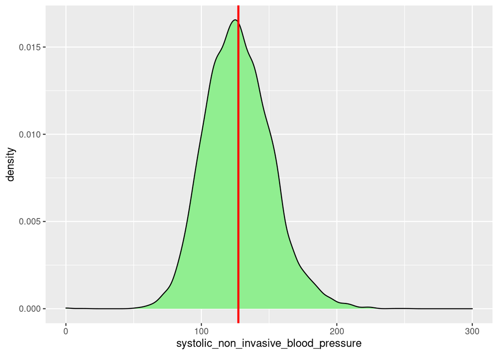

```r
msniBP <- mean(chartevents_tble$systolic_non_invasive_blood_pressure,
               na.rm = TRUE)
ggplot(data = chartevents_tble) +
  geom_density(mapping = aes(systolic_non_invasive_blood_pressure),
               fill = "light green") +
  geom_vline(xintercept = msniBP, size = 1, color = "red") +
  xlim(0, 300)
```

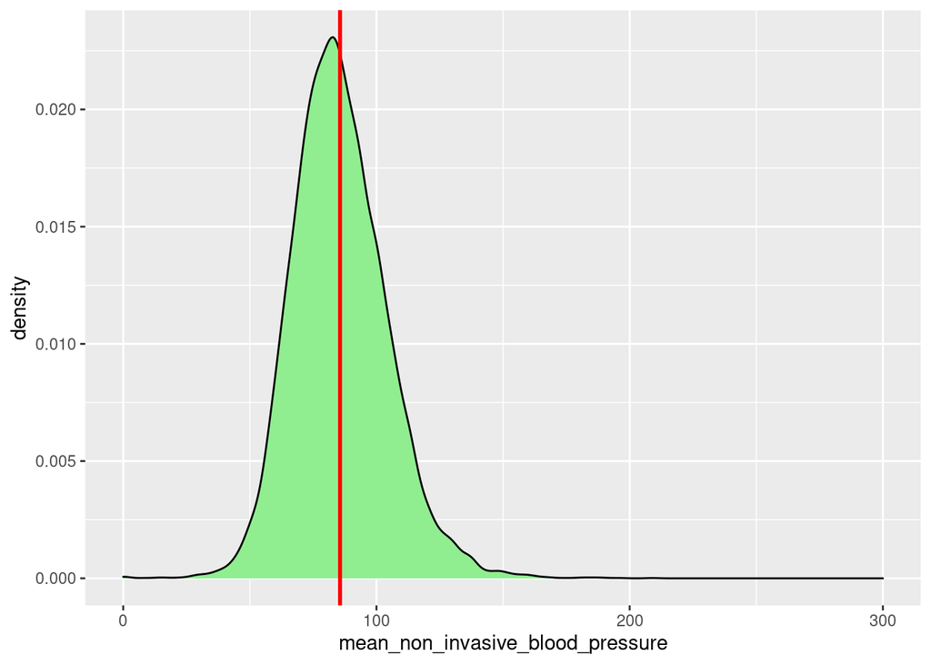

```r
mmniBP <- mean(chartevents_tble$mean_non_invasive_blood_pressure, na.rm = TRUE)
ggplot(data = chartevents_tble) +
  geom_density(mapping = aes(mean_non_invasive_blood_pressure),
               fill = "light green") +
  geom_vline(xintercept = mmniBP, size = 1, color = "red") +
  xlim(0, 300)
```

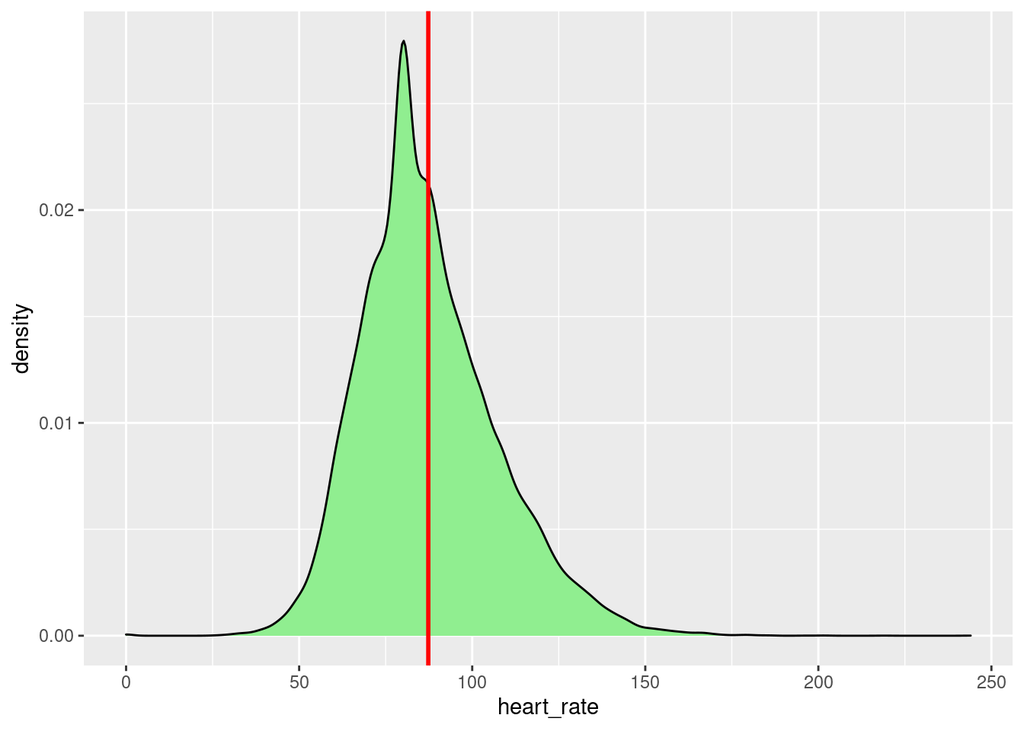

```r
mheart_rate <- mean(chartevents_tble$heart_rate, na.rm = TRUE)
ggplot(data = chartevents_tble) +
  geom_density(mapping = aes(heart_rate), fill = "light green") +
  geom_vline(xintercept = mheart_rate, size = 1, color = "red")
```

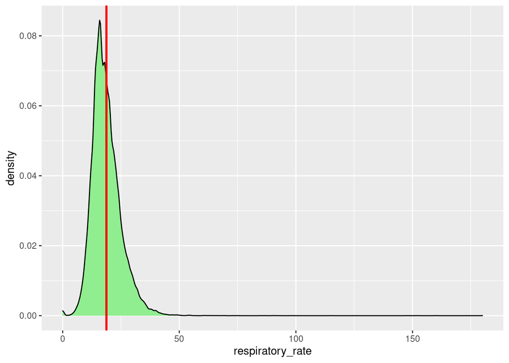

```r
mrespiratory_rate <- mean(chartevents_tble$respiratory_rate, na.rm = TRUE)
ggplot(data = chartevents_tble) +
  geom_density(mapping = aes(respiratory_rate), fill = "light green") +
  geom_vline(xintercept = mrespiratory_rate, size = 1, color = "red")
```

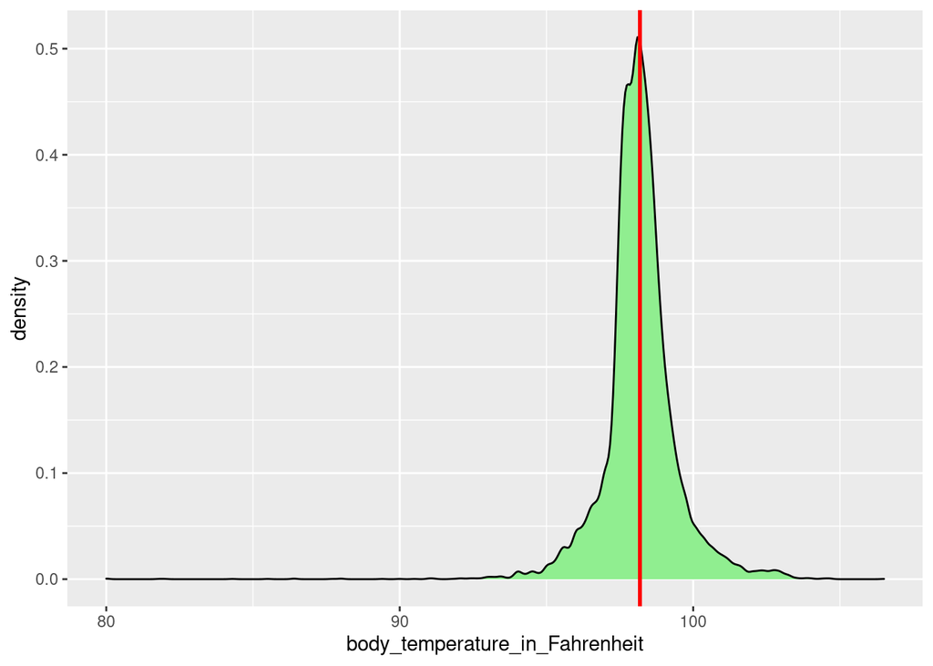

```r
mtemp <- mean(chartevents_tble$body_temperature_in_Fahrenheit, na.rm = TRUE)
ggplot(data = chartevents_tble) +
  geom_density(mapping = aes(body_temperature_in_Fahrenheit),
               fill = "light green") +
  geom_vline(xintercept = mtemp, size = 1, color = "red")
```

## Q7. Putting things together

Let us create a tibble `mimic_icu_cohort` for all ICU stays, where rows are

- first ICU stay of each unique adult (age at admission > 18)

and columns contain at least following variables

- all variables in `icustays.csv.gz`
- all variables in `admission.csv.gz`
- all variables in `patients.csv.gz`
- first lab measurements during ICU stay
- first vital measurements during ICU stay
- an indicator variable `thirty_day_mort` whether the patient died within 30 days of hospital admission (30 day mortality)

```r
admissions_tble <- admissions_tble %>%
                   group_by(subject_id) %>%
                   arrange(admittime) %>%
                   distinct(subject_id, .keep_all = TRUE)


mimic_icu_cohort1 <- full_join(icustays_tble, admissions_tble,
  by = "subject_id")

mimic_icu_cohort2 <- full_join(mimic_icu_cohort1, patients_tble,
  by = "subject_id")

mimic_icu_cohort3 <- full_join(mimic_icu_cohort2, labevents_tble,
  by = "subject_id")

mimic_icu_cohort <- full_join(mimic_icu_cohort3, chartevents_tble,
  by = "subject_id")
```

```r
mimic_icu_cohort$thirty_day_mort <- rep(NA, 53150)

for (i in 1:53150) {
  if (is.na(mimic_icu_cohort$deathtime[i])) {
    mimic_icu_cohort$thirty_day_mort[i] <- 0
  }
  else if (mimic_icu_cohort$deathtime[i] - mimic_icu_cohort$admittime[i] > 30) {
    mimic_icu_cohort$thirty_day_mort[i] <- 0
  }
  else {
    mimic_icu_cohort$thirty_day_mort[i] <- 1
  }
}
```

## Q8. Exploratory data analysis (EDA)

Summarize following information using appropriate numerics or graphs.

- `thirty_day_mort` vs demographic variables (ethnicity, language, insurance, marital_status, gender, age at hospital admission)

```r
mimic_icu_cohort %>%
  group_by(ethnicity) %>%
  summarise(mean = mean(thirty_day_mort))
```

```
## # A tibble: 8 × 2
##   ethnicity                       mean
##   <chr>                          <dbl>
## 1 AMERICAN INDIAN/ALASKA NATIVE 0.0532
## 2 ASIAN                         0.0463
## 3 BLACK/AFRICAN AMERICAN        0.0311
## 4 HISPANIC/LATINO               0.0354
## 5 OTHER                         0.0581
## 6 UNABLE TO OBTAIN              0.136
## 7 UNKNOWN                       0.181
## 8 WHITE                         0.0502
```

```r
mimic_icu_cohort %>%
  group_by(language) %>%
  summarise(mean = mean(thirty_day_mort))
```

```
## # A tibble: 2 × 2
##   language   mean
##   <chr>     <dbl>
## 1 ?        0.0622
## 2 ENGLISH  0.0648
```

```r
mimic_icu_cohort %>%
  group_by(insurance) %>%
  summarise(mean = mean(thirty_day_mort))
```

```
## # A tibble: 3 × 2
##   insurance   mean
##   <chr>      <dbl>
## 1 Medicaid  0.0490
## 2 Medicare  0.0804
## 3 Other     0.0542
```

```r
mimic_icu_cohort %>%
  group_by(marital_status) %>%
  summarise(mean = mean(thirty_day_mort))
```

```
## # A tibble: 5 × 2
##   marital_status   mean
##   <chr>           <dbl>
## 1 DIVORCED       0.0484
## 2 MARRIED        0.0494
## 3 SINGLE         0.0397
## 4 WIDOWED        0.0795
## 5 <NA>           0.207
```

```r
mimic_icu_cohort %>%
  group_by(gender) %>%
  summarise(mean = mean(thirty_day_mort))
```

```
## # A tibble: 2 × 2
##   gender   mean
##   <fct>   <dbl>
## 1 F      0.0671
## 2 M      0.0625
```

```r
mimic_icu_cohort %>%
  group_by(thirty_day_mort) %>%
  summarise(mean = mean(anchor_age))
```

```
## # A tibble: 2 × 2
##   thirty_day_mort  mean
##             <dbl> <dbl>
## 1               0  63.0
## 2               1  70.2
```

- `thirty_day_mort` vs first lab measurements

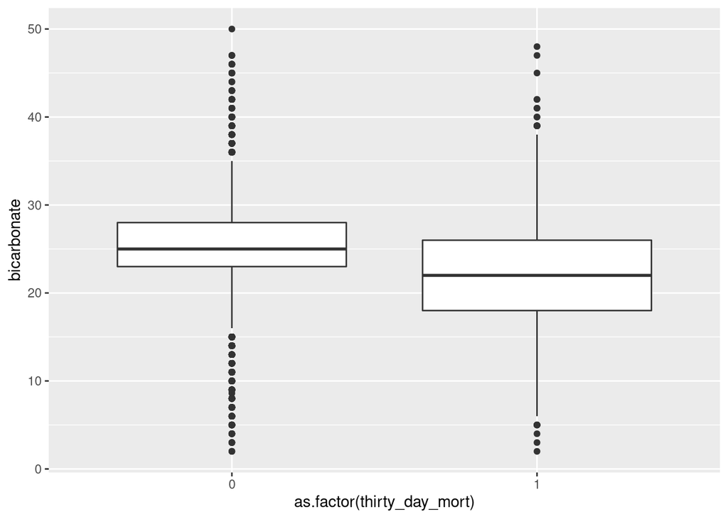

```r
ggplot(data = mimic_icu_cohort) +
    geom_boxplot(mapping = aes(x = as.factor(thirty_day_mort), y = bicarbonate))
```

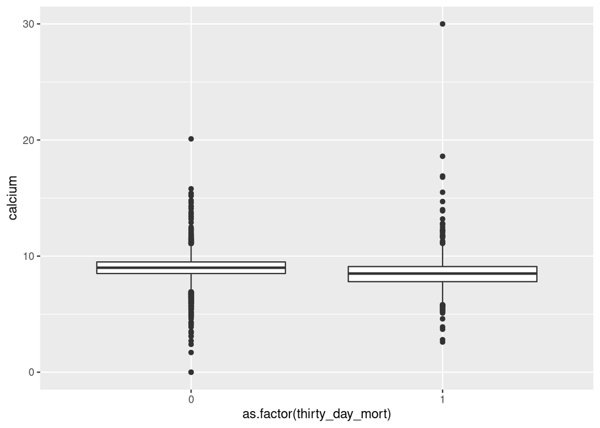

```r
ggplot(data = mimic_icu_cohort) +
    geom_boxplot(mapping = aes(x = as.factor(thirty_day_mort), y = calcium))
```

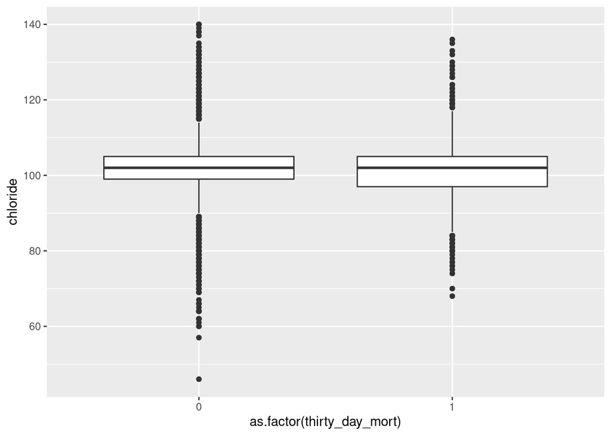

```r
ggplot(data = mimic_icu_cohort) +
    geom_boxplot(mapping = aes(x = as.factor(thirty_day_mort), y = chloride))
```

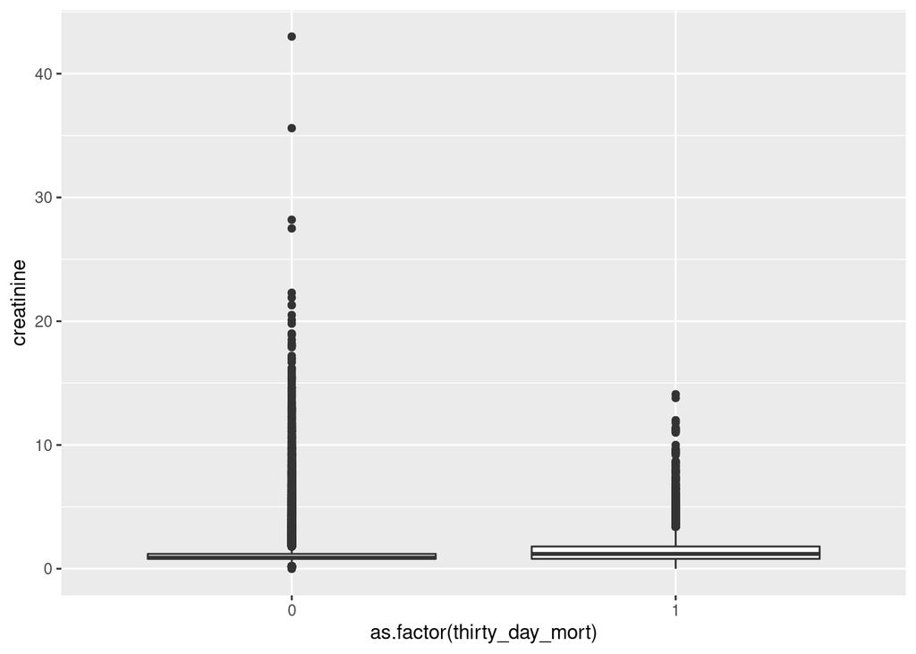

```r
ggplot(data = mimic_icu_cohort) +
    geom_boxplot(mapping = aes(x = as.factor(thirty_day_mort), y = creatinine))
```

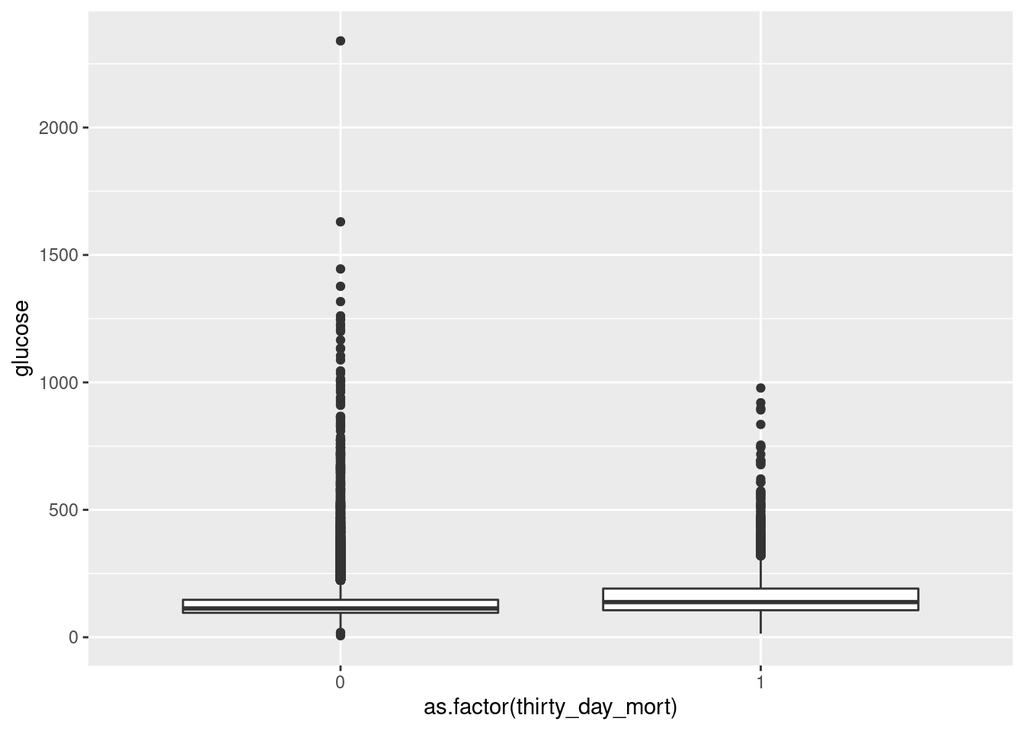

```r
ggplot(data = mimic_icu_cohort) +
    geom_boxplot(mapping = aes(x = as.factor(thirty_day_mort), y = glucose))
```

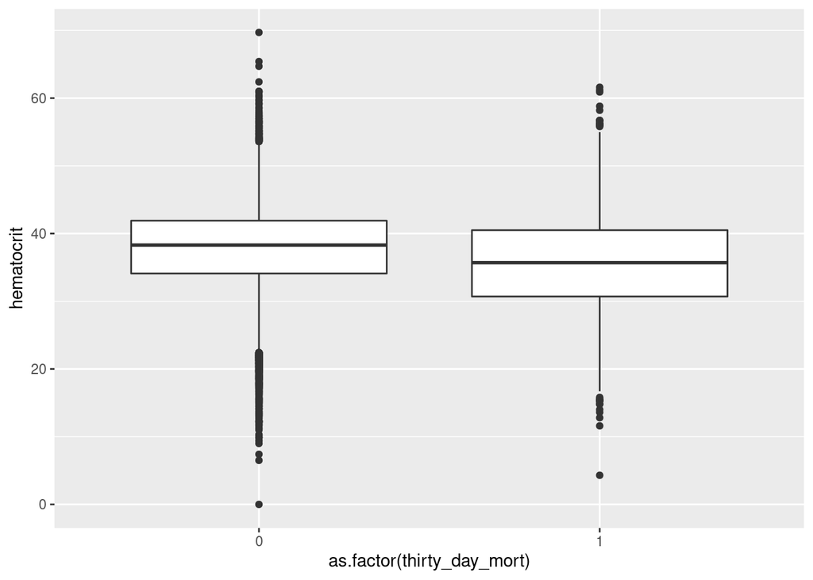

```r
ggplot(data = mimic_icu_cohort) +
    geom_boxplot(mapping = aes(x = as.factor(thirty_day_mort), y = hematocrit))
```

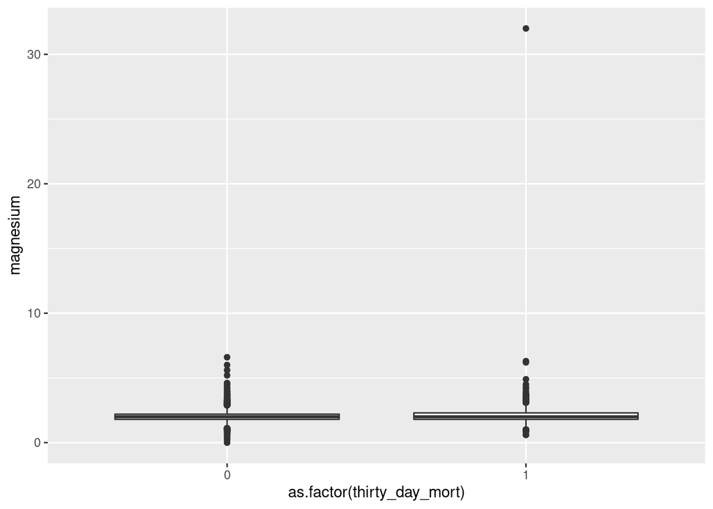

```r
ggplot(data = mimic_icu_cohort) +
    geom_boxplot(mapping = aes(x = as.factor(thirty_day_mort), y = magnesium))
```

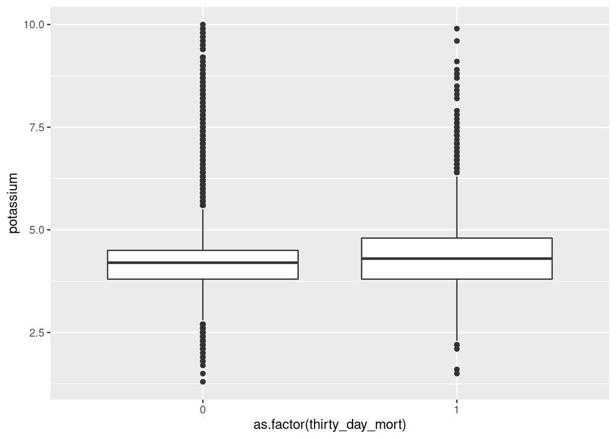

```r
ggplot(data = mimic_icu_cohort) +
    geom_boxplot(mapping = aes(x = as.factor(thirty_day_mort), y = potassium))
```

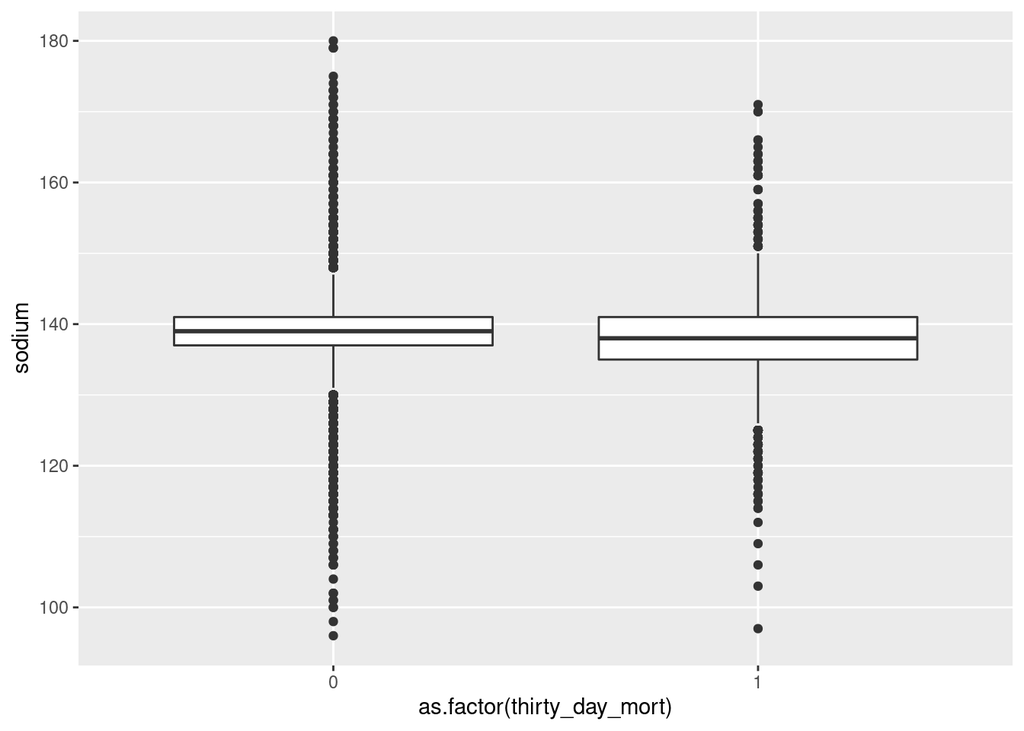

```r
ggplot(data = mimic_icu_cohort) +
    geom_boxplot(mapping = aes(x = as.factor(thirty_day_mort), y = sodium))
```

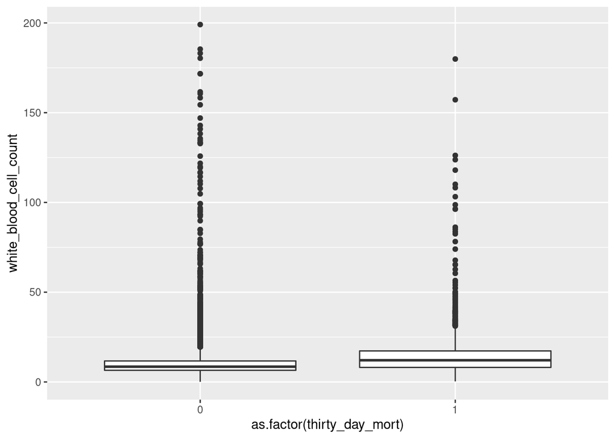

```r
ggplot(data = mimic_icu_cohort) +
    geom_boxplot(mapping = aes(x = as.factor(thirty_day_mort),
                               y = white_blood_cell_count))
```

- `thirty_day_mort` vs first vital measurements

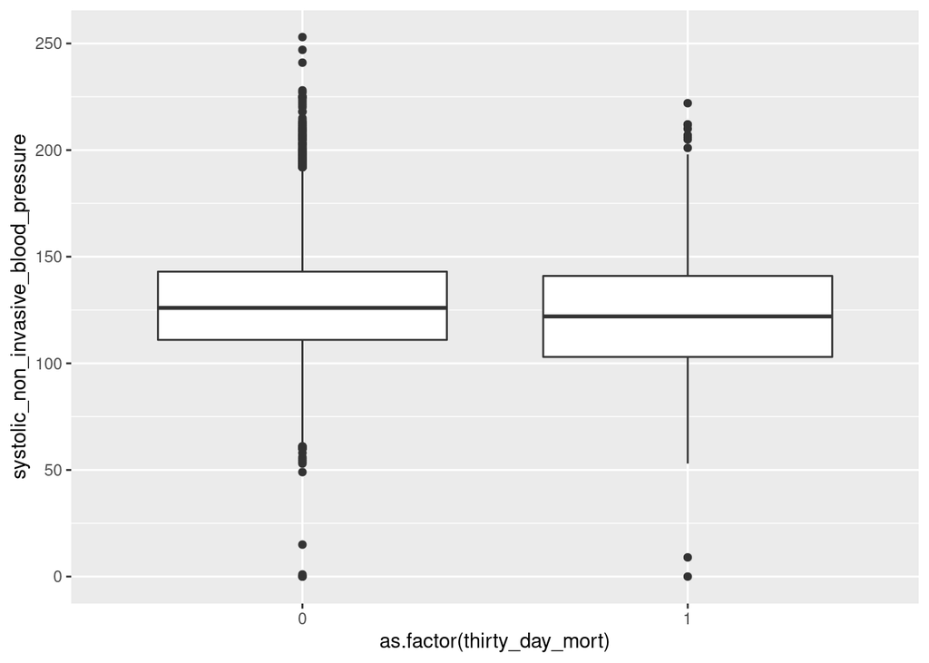

```r
ggplot(data = mimic_icu_cohort) +
    geom_boxplot(mapping = aes(x = as.factor(thirty_day_mort),
                               y = systolic_non_invasive_blood_pressure))
```

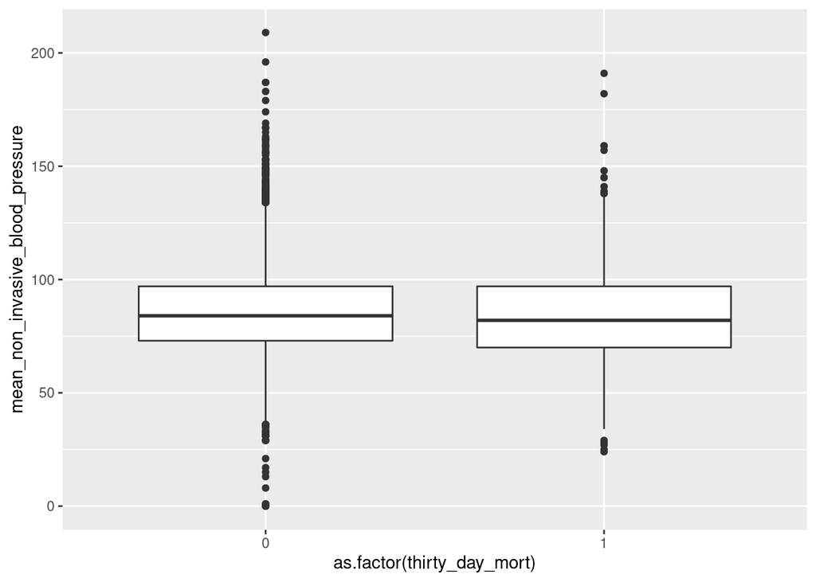

```r
ggplot(data = mimic_icu_cohort) +
    geom_boxplot(mapping = aes(x = as.factor(thirty_day_mort),
                               y = mean_non_invasive_blood_pressure))
```